# **Logistic regression**

**Summary of week3 study**

- *In week3, I self-studied some data wrangling skills (join,mutate etc.), logistic regression, cross validation from [DataCamp](https://campus.datacamp.com/courses/helsinki-open-data-science/logistic-regression?ex=1);*
- *Logistic regression is about modeling categorical targets using related variables*

```r
## Loading packages
library(dplyr)
```

```r
library(tidyr)
library(ggplot2)
library(GGally)
library(boot)
```

## 1. Read the data

In this week, we will use logisitic regression to build a model to predict alcohol consumption (AC). The data is processed from the [online data](https://archive.ics.uci.edu/ml/datasets/Student+Performance). There are two questionaires in the website. I have used 13 variables of both (`school`,`sex`,`age`,`address`,`famsize`,`Pstatus`,`Medu`,`Fedu`,`Mjob`,`Fjob`,`reason`,`nursery`,`internet`) to join the data. The remaining data is combined as mean if they are numeric or kept if they are other data types.

```r
## Reading data to alc
data <- "/Users/qingli/Documents/GitHub/IODS-project/Data/processed_alc_data_w3.csv"
alc <- read.csv(data)
colnames(alc)
```

```
##  [1] "school"     "sex"        "age"        "address"    "famsize"
##  [6] "Pstatus"    "Medu"       "Fedu"       "Mjob"       "Fjob"
## [11] "reason"     "nursery"    "internet"   "guardian"   "traveltime"
## [16] "studytime"  "failures"   "schoolsup"  "famsup"     "paid"
## [21] "activities" "higher"     "romantic"   "famrel"     "freetime"
## [26] "goout"      "Dalc"       "Walc"       "health"     "absences"
## [31] "G1"         "G2"         "G3"         "alc_use"    "high_use"
```

```r
str(alc)
```

```
## 'data.frame':    382 obs. of  35 variables:
##  $ school    : Factor w/ 2 levels "GP","MS": 1 1 1 1 1 1 1 1 1 1 ...
##  $ sex       : Factor w/ 2 levels "F","M": 1 1 1 1 1 2 2 1 2 2 ...
##  $ age       : int  18 17 15 15 16 16 16 17 15 15 ...
##  $ address   : Factor w/ 2 levels "R","U": 2 2 2 2 2 2 2 2 2 2 ...
##  $ famsize   : Factor w/ 2 levels "GT3","LE3": 1 1 2 1 1 2 2 1 2 1 ...
##  $ Pstatus   : Factor w/ 2 levels "A","T": 1 2 2 2 2 2 2 1 1 2 ...
##  $ Medu      : int  4 1 1 4 3 4 2 4 3 3 ...
##  $ Fedu      : int  4 1 1 2 3 3 2 4 2 4 ...
##  $ Mjob      : Factor w/ 5 levels "at_home","health",..: 1 1 1 2 3 4 3 3 4 3 ...
##  $ Fjob      : Factor w/ 5 levels "at_home","health",..: 5 3 3 4 3 3 3 5 3 3 ...
##  $ reason    : Factor w/ 4 levels "course","home",..: 1 1 3 2 2 4 2 2 2 2 ...
##  $ nursery   : Factor w/ 2 levels "no","yes": 2 1 2 2 2 2 2 2 2 2 ...
##  $ internet  : Factor w/ 2 levels "no","yes": 1 2 2 2 1 2 2 1 2 2 ...
##  $ guardian  : Factor w/ 3 levels "father","mother",..: 2 1 2 2 1 2 2 2 2 2 ...
```

[output cut: 21 more lines]

The explanations for the variables:

- `school` - student’s school (binary: ‘GP’ - Gabriel Pereira or ‘MS’ - Mousinho da Silveira) +`sex` - student’s sex (binary: ‘F’ - female or ‘M’ - male)
- `age` - student’s age (numeric: from 15 to 22)
- `address` - student’s home address type (binary: ‘U’ - urban or ‘R’ - rural)
- `famsize` - family size (binary: ‘LE3’ - less or equal to 3 or ‘GT3’ - greater than 3)
- `Pstatus` - parent’s cohabitation status (binary: ‘T’ - living together or ‘A’ - apart) + `Medu` - mother’s education (numeric: 0 - none, 1 - primary education (4th grade), 2 = 5th to 9th grade, 3 = secondary education or 4 = higher education)
- `Fedu` - father’s education (numeric: 0 - none, 1 - primary education (4th grade), 2 = 5th to 9th grade, 3 = secondary education or 4 = higher education)
- `Mjob` - mother’s job (nominal: ‘teacher’, ‘health’ care related, civil ‘services’ (e.g. administrative or police), ‘at_home’ or ‘other’)
- `Fjob` - father’s job (nominal: ‘teacher’, ‘health’ care related, civil ‘services’ (e.g. administrative or police), ‘at_home’ or ‘other’)
- `reason` - reason to choose this school (nominal: close to ‘home’, school ‘reputation’, ‘course’ preference or ‘other’)
- `guardian` - student’s guardian (nominal: ‘mother’, ‘father’ or ‘other’)
- `traveltime` - home to school travel time (numeric: 1 - <15 min., 2 - 15 to 30 min., 3 - 30 min. to 1 hour, or 4 - >1 hour)
- `studytime` - weekly study time (numeric: 1 - <2 hours, 2 - 2 to 5 hours, 3 - 5 to 10 hours, or 4 - >10 hours)
- `failures` - number of past class failures (numeric: n if 1<=n<3, else 4)
- `schoolsup` - extra educational support (binary: yes or no)
- `famsup` - family educational support (binary: yes or no)
- `paid` - extra paid classes within the course subject (Math or Portuguese) (binary: yes or no)
- `activities` - extra-curricular activities (binary: yes or no)
- `nursery` - attended nursery school (binary: yes or no)
- `higher` - wants to take higher education (binary: yes or no)
- `internet` - Internet access at home (binary: yes or no)
- `romantic` - with a romantic relationship (binary: yes or no)
- `famrel` - quality of family relationships (numeric: from 1 - very bad to 5 - excellent)
- `freetime` - free time after school (numeric: from 1 - very low to 5 - very high)
- `goout` - going out with friends (numeric: from 1 - very low to 5 - very high)
- `Dalc` - workday alcohol consumption (numeric: from 1 - very low to 5 - very high)
- `Walc` - weekend alcohol consumption (numeric: from 1 - very low to 5 - very high)
- `health` - current health status (numeric: from 1 - very bad to 5 - very good)
- `absences` - number of school absences (numeric: from 0 to 93)

These grades are related with the course subject, Math or Portuguese:

- `G1` - first period grade (numeric: from 0 to 20)
- `G2` - second period grade (numeric: from 0 to 20)
- `G3` - final grade (numeric: from 0 to 20, output target)

## 2. Select alcohol consumption (AC) related variables

To predict the alcohol consumption, I think the folowing variables might be associated:

- `paid`: the extra money can help to buy alcohol.
- `goout`: there will be more chance to drink alcohol with friends if they go out very often.
- `famrel`: people with higher AC are unlikely to have bad family relationships.
- `absences`: number of school absences is a sign for who drinks often and cannot make to school.

## 3. Explore the relationship between the selected variables with alcohol consumption (AC)

```r
## high_use vs paid
alc %>% group_by(paid,high_use) %>% summarise(count=n())
```

```
## # A tibble: 4 x 3
## # Groups:   paid [?]
##   paid  high_use count
##   <fct> <lgl>    <int>
## 1 no    FALSE      148
## 2 no    TRUE        57
## 3 yes   FALSE      120
## 4 yes   TRUE        57
```

The student got extra paid or not seemed not affect AC.

```r
## high_use vs goout
high_AC_goout_mean <- mean(alc$goout[alc$high_use == "TRUE"])
low_AC_goout_mean <- mean(alc$goout[alc$high_use == "FALSE"])

print(c("high AC group goout_mean",high_AC_goout_mean,
        "low AC group goout_mean",low_AC_goout_mean))
```

```
## [1] "high AC group goout_mean" "3.71929824561404"
## [3] "low AC group goout_mean"  "2.8544776119403"
```

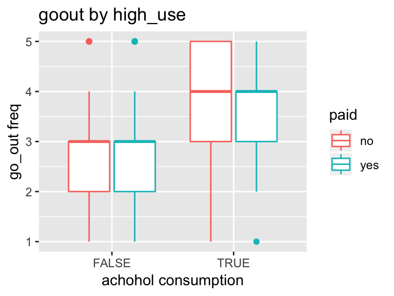

```r
g1 <- ggplot(alc, aes(x = high_use, y = goout,col=paid)) + geom_boxplot() +
  ggtitle("goout by high_use") + ylab("go_out freq") +xlab("achohol consumption")

g1
```

The students who have higher AC are more frequently going out with friends. The mean goout frequency for higher AC group is 3.7 compared with 2.8 in lower AC group.

```r
## high_use vs family relationship
high_AC_famrel_mean <- mean(alc$famrel[alc$high_use == "TRUE"])
low_AC_famrel_mean <- mean(alc$famrel[alc$high_use == "FALSE"])
print(c("high AC group family relationship status:",
        high_AC_famrel_mean,"low AC group family relationship status:",low_AC_famrel_mean))
```

```
## [1] "high AC group family relationship status:"
## [2] "3.78070175438596"
## [3] "low AC group family relationship status:"
## [4] "4.00373134328358"
```

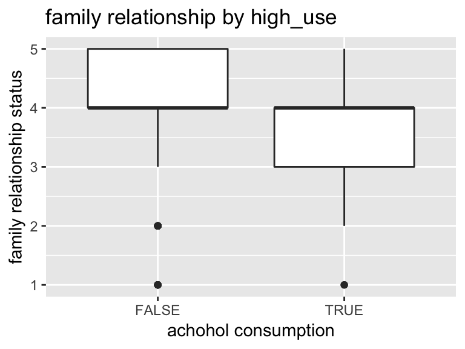

```r
g2 <- ggplot(alc, aes(x = high_use, y = famrel)) + geom_boxplot() +
 ggtitle("family relationship by high_use") +ylab("family relationship status") +xlab("achohol consumption")
g2
```

The family relationship status in students with higher AC and lower AC does not show a big difference from the mean of both group (3.7 and 4.0, respectively). But it looks different from the boxplot.

```r
## high_use vs absence
high_AC_absence_mean <- mean(alc$health[alc$high_use == "TRUE"])
low_AC_absence_mean <- mean(alc$health[alc$high_use == "FALSE"])

print(c("high_AC group absence times (mean):",high_AC_absence_mean,
        "low_AC group absence times (mean):",low_AC_absence_mean))
```

```
## [1] "high_AC group absence times (mean):"
## [2] "3.70175438596491"
## [3] "low_AC group absence times (mean):"
## [4] "3.51865671641791"
```

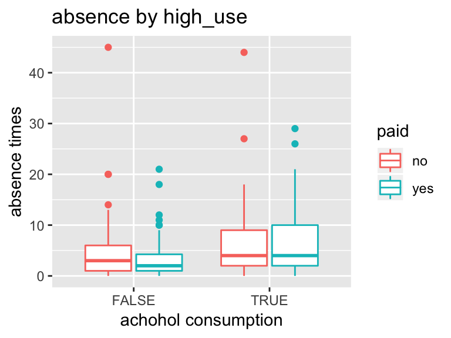

```r
g3 <- ggplot(alc, aes(x = high_use, y = absences, col=paid)) +
 geom_boxplot() + ggtitle("absence by high_use") +ylab("absence times") +xlab("achohol consumption")
g3
```

## 4. Logistic regression

```r
m <- glm(high_use ~ paid + goout + famrel + absences, data = alc, family = "binomial")
summary(m)
```

```
##
## Call:
## glm(formula = high_use ~ paid + goout + famrel + absences, family = "binomial",
##     data = alc)
##
## Deviance Residuals:
##     Min       1Q   Median       3Q      Max
## -1.9872  -0.7845  -0.5282   0.8936   2.4790
##
## Coefficients:
##             Estimate Std. Error z value Pr(>|z|)
## (Intercept) -2.56121    0.65303  -3.922 8.78e-05 ***
## paidyes      0.30183    0.24891   1.213 0.225270
## goout        0.77519    0.12028   6.445 1.16e-10 ***
## famrel      -0.34796    0.13566  -2.565 0.010318 *
## absences     0.07621    0.02188   3.484 0.000494 ***
## ---
## Signif. codes:  0 '***' 0.001 '**' 0.01 '*' 0.05 '.' 0.1 ' ' 1
##
## (Dispersion parameter for binomial family taken to be 1)
##
##     Null deviance: 465.68  on 381  degrees of freedom
## Residual deviance: 394.31  on 377  degrees of freedom
## AIC: 404.31
##
## Number of Fisher Scoring iterations: 4
```

```r
odd_ratio <- coef(m) %>% exp
CI <- confint(m) %>% exp
cbind(odd_ratio,CI)
```

```
##              odd_ratio      2.5 %    97.5 %
## (Intercept) 0.07721094 0.02069002 0.2698292
## paidyes     1.35233771 0.83100065 2.2091855
## goout       2.17100371 1.72550406 2.7679697
## famrel      0.70612502 0.53977795 0.9205137
## absences    1.07918726 1.03504151 1.1291747
```

- The odds ratio for `Intercept`(0.07) means the odds of being higher AC is 0.07 times of the odds being lower AC when other variables are zero.
- The odds ratio for `paidyes` means the odds for `paidyes` are about 1.35 times of the odds for `paidno`, and in the range of values [0.83100065 2.2091855] that you can be 95% certain to find the true mean of the OR.
- The odds ratios and 95 confidence intervals are listed for other three numeric variables (e.g. `goout`). The odds of being higher AC is 2.17 times higher than the odds of being lower AC if we increase goout a one-unit higher. The range of [1.72550406 2.7679697] is that we can be 95% certain to find the true mean of the OR.

Therefore, we are only considering the significantly contirbuted variables in our new model which will be used for prediction.

```r
m_new <- glm(high_use ~ goout + famrel + absences, data = alc, family = "binomial")
summary(m_new)
```

```
##
## Call:
## glm(formula = high_use ~ goout + famrel + absences, family = "binomial",
##     data = alc)
##
## Deviance Residuals:
##     Min       1Q   Median       3Q      Max
## -1.9018  -0.7731  -0.5466   0.9002   2.4180
##
## Coefficients:
##             Estimate Std. Error z value Pr(>|z|)
## (Intercept) -2.38825    0.63161  -3.781 0.000156 ***
## goout        0.77071    0.11981   6.433 1.25e-10 ***
## famrel      -0.34986    0.13534  -2.585 0.009735 **
## absences     0.07446    0.02174   3.425 0.000615 ***
## ---
## Signif. codes:  0 '***' 0.001 '**' 0.01 '*' 0.05 '.' 0.1 ' ' 1
##
## (Dispersion parameter for binomial family taken to be 1)
##
##     Null deviance: 465.68  on 381  degrees of freedom
## Residual deviance: 395.79  on 378  degrees of freedom
## AIC: 403.79
##
## Number of Fisher Scoring iterations: 4
```

## 5. Model prediction

```r
## use the new model to predict the probabilities for each sample
probabilities <- predict(m_new, type = "response")

## add probabilities and prediction to alc
alc <- mutate(alc, probabilities = probabilities)
alc <- mutate(alc, prediction = probabilities>0.5)

## calculate 2x2 cross tabulation of predictions versus the actual values
table(high_use = alc$high_use, prediction = alc$prediction)
```

```
##         prediction
## high_use FALSE TRUE
##    FALSE   244   24
##    TRUE     69   45
```

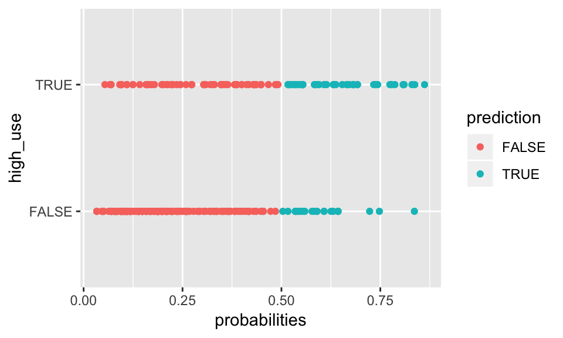

```r
## calculate 2x2 cross tabulation of predictions versus the actual values in proportion
ggplot(alc, aes(x = probabilities, y =high_use,col = prediction)) + geom_point()
```

```r
table(high_use = alc$high_use, prediction = alc$prediction) %>% prop.table %>% addmargins
```

```
##         prediction
## high_use      FALSE       TRUE        Sum
##    FALSE 0.63874346 0.06282723 0.70157068
##    TRUE  0.18062827 0.11780105 0.29842932
##    Sum   0.81937173 0.18062827 1.00000000
```

From the prediction result, there are 75.6% (`0.63874346+0.11780105=0.7565445`) of the samples out of 382 samples are accuretely predicted by our model.

```r
## the mean prediction error
loss_func <- function(class, prob) {
  n_wrong <- abs(class - prob) > 0.5 ## the class is either 'TRUE'(1) or 'FALSE' (0).
  mean(n_wrong)
}
## call the loss function to calculate the wrong prediction rate
loss_func(class = alc$high_use, prob = alc$probabilities)
```

```
## [1] 0.2434555
```

Thus, the error prediction rate is around 24.3%, which matches with our accuracy rate `1-accuracy rate(75.6%)`.

## 6. Cross validation for model performance validation

```r
cv <- cv.glm(data = alc, cost = loss_func, glmfit = m_new, K = 10)
cv$delta[1]
```

```
## [1] 0.2513089
```

```r
m_tutorial <- glm(high_use ~ failures + absences + sex, data = alc, family = "binomial")
cv_tutorial <- cv.glm(data = alc, cost = loss_func, glmfit = m_tutorial, K = 10)
cv_tutorial$delta[1]
```

```
## [1] 0.2591623
```

The prediction error for the model given in the tutorial is 0.259, which is higher than our current model. Our model shows better performance.

## 7. Model comparison

```r
## Use 8 variables as predictors
m1 <- glm(high_use ~ failures + absences + sex + paid + goout + famrel + higher + famsize, data = alc, family = "binomial")
## summary the model
summary (m1)
```

```
##
## Call:
## glm(formula = high_use ~ failures + absences + sex + paid + goout +
##     famrel + higher + famsize, family = "binomial", data = alc)
##
## Deviance Residuals:
##     Min       1Q   Median       3Q      Max
## -1.7657  -0.7238  -0.4910   0.6833   2.6906
##
## Coefficients:
##             Estimate Std. Error z value Pr(>|z|)
## (Intercept) -3.10908    0.90968  -3.418 0.000631 ***
## failures     0.37302    0.21838   1.708 0.087610 .
## absences     0.08232    0.02250   3.659 0.000253 ***
## sexM         1.01413    0.26839   3.779 0.000158 ***
## paidyes      0.55953    0.26898   2.080 0.037503 *
## goout        0.74982    0.12473   6.012 1.84e-09 ***
## famrel      -0.37065    0.14234  -2.604 0.009216 **
## higheryes   -0.12972    0.57954  -0.224 0.822886
## famsizeLE3   0.28345    0.28081   1.009 0.312779
## ---
## Signif. codes:  0 '***' 0.001 '**' 0.01 '*' 0.05 '.' 0.1 ' ' 1
##
## (Dispersion parameter for binomial family taken to be 1)
##
##     Null deviance: 465.68  on 381  degrees of freedom
## Residual deviance: 372.39  on 373  degrees of freedom
## AIC: 390.39
##
## Number of Fisher Scoring iterations: 4
```

```r
## For training data
probabilities_m1 <- predict(m1, type = "response")
m1_ave_wrong_pred <- loss_func(class = alc$high_use, prob = probabilities_m1)
m1_ave_wrong_pred
```

```
## [1] 0.2146597
```

```r
## For testing data
cv_m1 <- cv.glm(data = alc, cost = loss_func, glmfit = m1, K = 10)
cv_m1_wrong_pred <- cv_m1$delta[1]
cv_m1_wrong_pred
```

```
## [1] 0.2408377
```

**To draw prediction error for the traning and testing data for different model, we will then creat a dataframe to collect all the data as fellows:**

```r
## for the variables numbers 8,7,6,5 and 4 will be used for 5 models. For each of the model, we will collect its prediction error for training and testing data. So there are 10 vectors.
model_name <- NULL ## model name for each one, identified by their prediction variable numbers
types <- NULL ## to distinguish two types of prediction error for each model
values_collection<- replicate(10,0) ## initialize prediction error vector to ten zeros
## change the fisrt two prediction error values for model8
values_collection[c(1,2)] <- c(m1_ave_wrong_pred,cv_m1_wrong_pred)

## Change the model names and types using a loop:
for (i in c(8,7,6,5,4)){
  model_name <- c (model_name, replicate(2,paste("model",i,sep='')) )
  types <- c(types, c("traning","testing"))
}

## give the three vectors to our model collection dataframe.
model_collection <- data.frame(model=model_name,pred_error=values_collection,used_data=types)
## print model collection
model_collection
```

```
##     model pred_error used_data
## 1  model8  0.2146597   traning
## 2  model8  0.2408377   testing
## 3  model7  0.0000000   traning
## 4  model7  0.0000000   testing
## 5  model6  0.0000000   traning
## 6  model6  0.0000000   testing
## 7  model5  0.0000000   traning
## 8  model5  0.0000000   testing
## 9  model4  0.0000000   traning
## 10 model4  0.0000000   testing
```

**Now, we will call different models and collect their prediction erros to our model collection dataframe.**

```r
## for model7:
m <- glm(high_use ~ failures + absences + sex + paid + goout + famrel + higher, data = alc, family = "binomial")
## For training data
probabilities_m <- predict(m, type = "response")
m_ave_wrong_pred <- loss_func(class = alc$high_use, prob = probabilities_m)
## For testing data
cv_m <- cv.glm(data = alc, cost = loss_func, glmfit = m, K = 10)
cv_m_wrong_pred <- cv_m$delta[1]
values_collection[c(3,4)] <- c(m_ave_wrong_pred,cv_m_wrong_pred)

## for model6:

m <- glm(high_use ~ failures + absences + sex + paid + goout + famrel, data = alc, family = "binomial")
## For training data
probabilities_m <- predict(m, type = "response")
m_ave_wrong_pred <- loss_func(class = alc$high_use, prob = probabilities_m)
## For testing data
cv_m <- cv.glm(data = alc, cost = loss_func, glmfit = m, K = 10)
cv_m_wrong_pred <- cv_m$delta[1]
values_collection[c(5,6)] <- c(m_ave_wrong_pred,cv_m_wrong_pred)

## for model5:

m <- glm(high_use ~ absences + sex + paid + goout + famrel, data = alc, family = "binomial")
## For training data
probabilities_m <- predict(m, type = "response")
m_ave_wrong_pred <- loss_func(class = alc$high_use, prob = probabilities_m)
## For testing data
cv_m <- cv.glm(data = alc, cost = loss_func, glmfit = m, K = 10)
cv_m_wrong_pred <- cv_m$delta[1]
values_collection[c(7,8)] <- c(m_ave_wrong_pred,cv_m_wrong_pred)

## for model4:

m <- glm(high_use ~ absences + sex + goout + famrel, data = alc, family = "binomial")
## For training data
probabilities_m <- predict(m, type = "response")
m_ave_wrong_pred <- loss_func(class = alc$high_use, prob = probabilities_m)
## For testing data
cv_m <- cv.glm(data = alc, cost = loss_func, glmfit = m, K = 10)
cv_m_wrong_pred <- cv_m$delta[1]
values_collection[c(9,10)] <- c(m_ave_wrong_pred,cv_m_wrong_pred)
values_collection
```

```
##  [1] 0.2146597 0.2408377 0.2015707 0.2146597 0.2015707 0.2094241 0.2094241
##  [8] 0.2303665 0.2041885 0.2146597
```

We have collected all the prediction errors for all models. Next, we will draw the figure to compare them.

```r
model_order<-paste ("model",c(8,7,6,5,4),sep="")
model_collection$model <- factor(model_collection$model,levels=as.vector(model_order))
model_collection$pred_error <- values_collection
model_collection
```

```
##     model pred_error used_data
## 1  model8  0.2146597   traning
## 2  model8  0.2408377   testing
## 3  model7  0.2015707   traning
## 4  model7  0.2146597   testing
## 5  model6  0.2015707   traning
## 6  model6  0.2094241   testing
## 7  model5  0.2094241   traning
## 8  model5  0.2303665   testing
## 9  model4  0.2041885   traning
## 10 model4  0.2146597   testing
```

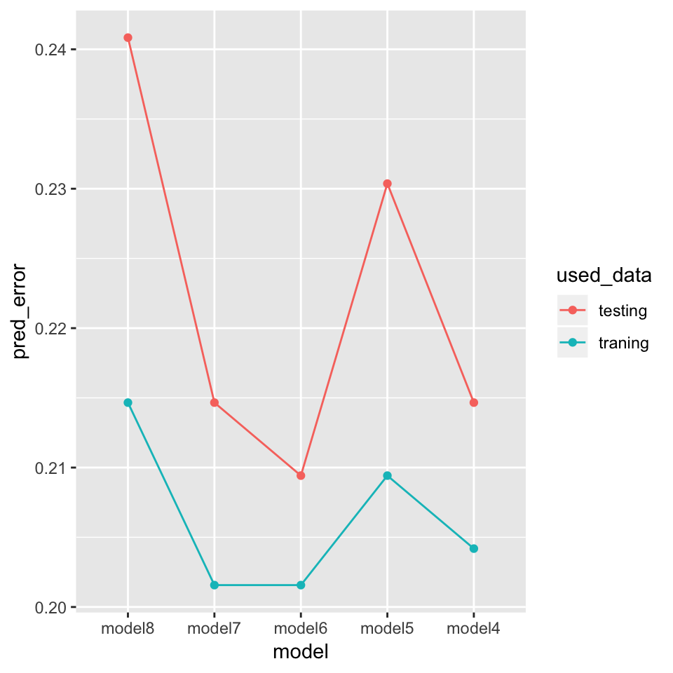

```r
ggplot(model_collection,aes(x=model,y=pred_error,col=used_data, group=used_data)) +geom_point() + geom_line()
```